# Estimate protein mass fractions for *Salmonella typhimurium*

x86_64-conda-linux-gnu

25 March, 2026

# Background

## Coarse-grained cellular economy model

This notebook analyzes mass spectrometry-based proteomics data for *Salmonella typhimurium*. The goal is to estimate relative mass fraction (percentage) of protein dedicated to particular functional groups. The functional groups we are interested in are major protein sectors such as:

- carbon and nutrient import (“Tra”)
- carbon metabolism to produce precursors such as Acetyl-CoA (“Cbn”)
- amino acid biosynthesis (“Aab”)
- translation and protein homeostasis (“Rib”)
- lipid and cell wall component biosynthesis (“Lpb”)
- Electron transport chain to re-generate ATP (“Etc”)
- Flagella and related motility proteins (“Fla”)
- All other proteins, which are not directly related to above groups (“Oth”)

Protein mass fractions are used to constrain a simplified cellular economy model of *Salmonella*. In particular, we want to calculate the protein investment of the above listed sectors. Then we can determine if, and how, experimentally observed protein allocation corresponds to optimal protein investment as predicted by the model. A focus of this analysis is the cost and benefit of the flagellum, an immense protein machinery which consumes both protein resources (10,000s of subunits) and ATP-derived rotational energy. We hypothesize that the cost of the flagellum machinery must be offset by an important benefit, such as increased motility in the gut lumen, and/or ability to break free from trapped states in the mucosa.

## Mutant strains used for modeling

- `EM16223`: △flhDC, 0 flagella (null mutant)
- `EM16224`: motB D33N (rotation-deficient mutant)
- `EM9662`: Ppro1-flhDC, 0-1 flagellum
- `EM9661`: PproA-flhDC, mostly 1 flagellum
- `TH9677`: **WT**, 3-4 flagella on average
- `TH5861`: **WT**, (fliC ON background, for comparison to motB mutant)
- `EM9660`: PproB-flhDC, 5-6 flagella
- `EM8513`: PproD-flhDC, 7-8 flagella

# Prerequisites

- load required packages
- either download and install in RStudio or set up an appropriate conda environment

```r
suppressPackageStartupMessages({
  library(tidyverse)
  library(KEGGREST)
  library(ggpubr)
  library(ggrepel)
  library(grDevices)
  library(ggh4x)
  library(colorspace)
})
```

Define global figure style, default colors, and a plot saving function (hidden chunk).

## Data import

Load raw data and reformat if needed.

```r
df <- read_csv("../tables/maxLFQ_protein_intensity_data.csv",
  show_col_types = FALSE,
  name_repair = function(x) {
    gsub("[._]", "_", tolower(x))
  }
) %>%
  select(-r_filename, -intensity_rank, -raw_protein_intensity) %>%
  rename(uniprot_id = pg_proteingroups, intensity = protein_intensity) %>%
  separate_longer_delim(uniprot_id, ";") %>%
  rename_with(function(x) {
    gsub("^r\\_", "", x)
  })

head(df)
```

| uniprot_id | intensity | condition | replicate |
| --- | --- | --- | --- |
| H9L410 | 6661.360 | EM16223 | 1 |
| H9L410 | 6762.225 | EM16223 | 2 |
| H9L410 | 7708.918 | EM16223 | 3 |
| H9L410 | 6574.982 | EM16223 | 4 |
| H9L410 | 7397.527 | EM8513 | 1 |
| H9L410 | 6951.821 | EM8513 | 2 |

## Data annotation

### Download pathway data from Uniprot

- different annotation columns are added to the main data frame, primarily genome annotation from [Uniprot](https://www.uniprot.org/) and [KEGG](https://www.genome.jp/kegg/)
- annotation data is dynamically downloaded for every update of this pipeline using the API
- full list of Uniprot metadata that can be queried is available [here](https://www.uniprot.org/help/api_queries)
- for Salmonella typhimurium LT2, the **taxonomy ID is 99287**

```r
taxid <- 99287
uniprot_columns <- c(
  "accession", "id", "protein_name", "gene_names", "organism_name",
  "length", "xref_kegg", "gene_oln", "cc_pathway",
  "go_id", "cc_subcellular_location"
)
uniprot_url <- paste0(
  "https://rest.uniprot.org/uniprotkb/stream?fields=",
  paste0(uniprot_columns, collapse = "%2C"),
  "&format=tsv&query=%28%28taxonomy_id%3A", taxid, "%29%29"
)

get_uniprot <- function(url, backup = NULL) {
  server_error <- simpleError("")
  df_uniprot <- tryCatch(
    {
      df <- read_tsv(url, col_types = cols()) %>%
        rename_with(tolower) %>%
        rename(
          uniprot_id = entry,
          uniprot_name = `entry name`,
          locus_tag = `gene names (ordered locus)`,
          gene_name_long = `gene names`,
          protein = `protein names`,
          gene_ontology_ids = `gene ontology ids`
        )
      return(df)
    },
    error = function(server_error) {
      if (file.exists(backup)) {
        warning("Uniprot server not available, falling back to import local Uniprot annotation.")
        return(read_csv(backup, col_types = cols(), name_repair = tolower))
      } else {
        warning("Uniprot server not available, and local uniprot file can't be found.")
      }
    }
  )
}

# download Uniprot data, and save a local backup copy if it doesn't exist
uniprot_backup <- "../tables/uniprot_annotation_backup.csv"
if (file.exists(uniprot_backup)) {
  df_uniprot <- read_csv(uniprot_backup, col_types = cols(), name_repair = tolower)
} else {
  df_uniprot <- get_uniprot(uniprot_url, uniprot_backup)
  write_csv(df_uniprot, uniprot_backup)
}
```

```r
df_uniprot <- df_uniprot %>%
  filter(organism == "Salmonella typhimurium (strain LT2 / SGSC1412 / ATCC 700720)") %>%
  mutate(kegg = str_remove_all(kegg, "stm:|;.*"))

head(df_uniprot)
```

| uniprot_id | uniprot_name | protein | gene_name_long | organism | length | kegg | locus_tag | pathway | gene_ontology_ids | subcellular location [cc] |
| --- | --- | --- | --- | --- | --- | --- | --- | --- | --- | --- |
| H9L427 | BIPA_SALTY | Large ribosomal subunit assembly factor BipA (EC 3.6.5.-) (50S ribosomal subunit assembly factor BipA) (GTP-binding protein BipA) (Ribosome-dependent GTPase BipA) | bipA STM4009 | Salmonella typhimurium (strain LT2 / SGSC1412 / ATCC 700720) | 607 | STM4009 | STM4009 | NA | GO:0000027; GO:0000049; GO:0003924; GO:0005525; GO:0005829; GO:0009409; GO:0010467; GO:0019843; GO:0043022; GO:0097216; GO:1990904 | SUBCELLULAR LOCATION: Cytoplasm {ECO:0000255\|HAMAP-Rule:MF_00849, ECO:0000305\|PubMed:18621905}. Note=During exponential growth the GTP-bound state associates 1:1 with 70S ribosomes. Under stress con… |
| H9L478 | PDUJ_SALTY | Bacterial microcompartment shell protein PduJ (Bacterial microcompartment protein homohexamer) (BMC-H) (Propanediol utilization protein PduJ) | pduJ STM2045 | Salmonella typhimurium (strain LT2 / SGSC1412 / ATCC 700720) | 91 | STM2045 | STM2045 | PATHWAY: Polyol metabolism; 1,2-propanediol degradation. {ECO:0000305\|PubMed:10498708}. | GO:0031472; GO:0051144 | SUBCELLULAR LOCATION: Bacterial microcompartment {ECO:0000269\|PubMed:12923081, ECO:0000269\|PubMed:24747050}. |
| O30916 | SOPB_SALTY | Inositol phosphate phosphatase SopB (EC 3.1.3.-) (Effector protein SopB) | sopB sigD STM1091 | Salmonella typhimurium (strain LT2 / SGSC1412 / ATCC 700720) | 561 | STM1091 | STM1091 | NA | GO:0005576; GO:0020003; GO:0023057; GO:0030308; GO:0039527; GO:0042577; GO:0044075; GO:0045740; GO:0045859; GO:0071944; GO:0141083 | SUBCELLULAR LOCATION: Secreted {ECO:0000250}. Note=Secreted via the type III secretion system 1 (SPI-1 T3SS). {ECO:0000250}. |
| O31041 | PDUD_SALTY | Propanediol dehydratase medium subunit (EC 4.2.1.28) (Diol dehydratase medium subunit) (DDH medium subunit) (Propanediol utilization protein PduD) | pduD STM2041 | Salmonella typhimurium (strain LT2 / SGSC1412 / ATCC 700720) | 224 | STM2041 | STM2041 | PATHWAY: Polyol metabolism; 1,2-propanediol degradation. {ECO:0000305\|PubMed:10498708}. | GO:0031419; GO:0031472; GO:0050215; GO:0051144 | SUBCELLULAR LOCATION: Bacterial microcompartment {ECO:0000269\|PubMed:10498708, ECO:0000269\|PubMed:11844753, ECO:0000269\|PubMed:12923081, ECO:0000269\|PubMed:21821773, ECO:0000269\|PubMed:26283792}.… |
| O31042 | PDUE_SALTY | Propanediol dehydratase small subunit (EC 4.2.1.28) (Diol dehydratase small subunit) (DDH small subunit) (Propanediol utilization protein PduE) | pduE STM2042 | Salmonella typhimurium (strain LT2 / SGSC1412 / ATCC 700720) | 173 | STM2042 | STM2042 | PATHWAY: Polyol metabolism; 1,2-propanediol degradation. {ECO:0000305\|PubMed:10498708}. | GO:0031419; GO:0031472; GO:0050215; GO:0051144 | SUBCELLULAR LOCATION: Bacterial microcompartment {ECO:0000269\|PubMed:10498708, ECO:0000269\|PubMed:11844753, ECO:0000269\|PubMed:12923081, ECO:0000269\|PubMed:21821773}. Note=Probably located inside … |
| O52222 | FLHC_SALTY | Flagellar transcriptional regulator FlhC | flhC STM1924 | Salmonella typhimurium (strain LT2 / SGSC1412 / ATCC 700720) | 192 | STM1924 | STM1924 | NA | GO:0000166; GO:0003677; GO:0005737; GO:0008270; GO:0044781; GO:0045893; GO:1902208 | SUBCELLULAR LOCATION: Cytoplasm {ECO:0000255\|HAMAP-Rule:MF_01891}. |

- inspect Uniprot pathway annotation as we need to assign each protein unambiguosly to one pathway
- the protein allocation modeling does not effectively support shared genes that are assigned to multiple pathways
- this is a simplification which is tolerable given that the model features less than 10 sectors (metabolic functions)

```r
df_uniprot %>%
  group_by(pathway) %>%
  summarize(genes = n()) %>%
  arrange(desc(genes)) %>%
  head()
```

| pathway | genes |
| --- | --- |
| NA | 3865 |
| PATHWAY: Polyol metabolism; 1,2-propanediol degradation. {ECO:0000305\|PubMed:10498708}. | 17 |
| PATHWAY: Amine and polyamine degradation; ethanolamine degradation. {ECO:0000269\|PubMed:3045078}. | 15 |
| PATHWAY: Bacterial outer membrane biogenesis; LPS O-antigen biosynthesis. | 5 |
| PATHWAY: Cell wall biogenesis; peptidoglycan biosynthesis. | 5 |
| PATHWAY: Cofactor biosynthesis; adenosylcobalamin biosynthesis. | 5 |

- the overview shows us that the pathway annotation is too detailed and fine-grained
- we need to re-assign the detailed pathways to our coarse-grained sectors
- consider KEGG (Brite) as another, alternative source of pathway annotation
- it provides a hierarchical classification of pathways that can be mapped to our sectors

### Download pathway data from KEGG

- for Salmonella typhimurium LT2, the KEGG ID is **stm**
- we use the `KEGGREST` R package to dynamically download pathway annotation from KEGG

```r
get_kegg <- function(id, backup = NULL) {
  server_error <- simpleError("")
  tryCatch(
    {
      df <- keggLink("pathway", id) %>%
        enframe(name = "locus", value = "kegg_pathway_id") %>%
        mutate(kegg_pathway_id = str_remove(kegg_pathway_id, "path:| ")) %>%
        # get list of pathways with name/ID pairs
        left_join(
          by = "kegg_pathway_id",
          keggList("pathway", id) %>%
            enframe(name = "kegg_pathway_id", value = "kegg_pathway")
        ) %>%
        # trim useless prefixes
        mutate(
          kegg = str_remove(locus, paste0(id, ":")),
          kegg_pathway_id = str_remove(kegg_pathway_id, "path:"),
          kegg_pathway = str_remove(kegg_pathway, " \\- .*$")
        )
      return(df)
    },
    error = function(server_error) {
      if (file.exists(backup)) {
        warning("KEGG server not available, falling back to import local KEGG annotation.")
        return(read_csv(backup, col_types = cols(), name_repair = tolower))
      } else {
        warning("KEGG server not available, and local KEGG file can't be found.")
      }
    }
  )
}

# kegg ID for Salmonella Typhimurium LT2
keggid <- "stm"
backup <- "../tables/kegg_annotation_backup.csv"
df_kegg <- get_kegg(keggid, backup)
if (!file.exists(backup)) {
  write_csv(df_kegg, backup)
}
```

- how many pathways do we have in total?
- overview about the most abundant pathways in KEGG annotation

```r
print(df_kegg %>% summarize(n_pathways = n_distinct(kegg_pathway)))
```

```
## # A tibble: 1 × 1
##   n_pathways
##        <int>
## 1        139
```

```r
df_kegg %>%
  group_by(kegg_pathway) %>%
  summarize(genes = n()) %>%
  arrange(desc(genes)) %>%
  head(10)
```

| kegg_pathway | genes |
| --- | --- |
| Metabolic pathways | 958 |
| Biosynthesis of secondary metabolites | 367 |
| Microbial metabolism in diverse environments | 307 |
| Two-component system | 214 |
| ABC transporters | 173 |
| Biosynthesis of cofactors | 159 |
| Biosynthesis of amino acids | 129 |
| Carbon metabolism | 115 |
| Aminoacyl-tRNA biosynthesis | 111 |
| Ribosome | 78 |

- it’s also important to investigate if genes are assigned to multiple pathways
- if this is the case, we need to decide how to handle these genes
- below is an overview of number of pathways assigned to each gene
- the majority is of genes is associated to >1 pathway

```r
df_kegg %>%
  group_by(kegg) %>%
  summarize(pathways_per_gene = n_distinct(kegg_pathway)) %>%
  count(pathways_per_gene)
```

| pathways_per_gene | n |
| --- | --- |
| 1 | 693 |
| 2 | 330 |
| 3 | 325 |
| 4 | 202 |
| 5 | 92 |
| 6 | 62 |
| 7 | 35 |
| 8 | 38 |
| 9 | 18 |
| 10 | 20 |

[output cut: 5 more lines]

- are the multiple pathways per gene related to each other, or completely different?
- we can investigate some random examples to get a feeling for the data
- the examples picked here have 3, 4, and 5 pathways assigned to them, and all are stringly related to each other

```r
filter(df_kegg, kegg == "PSLT064")
```

| locus | kegg_pathway_id | kegg_pathway | kegg |
| --- | --- | --- | --- |
| stm:PSLT064 | stm03030 | DNA replication | PSLT064 |
| stm:PSLT064 | stm03430 | Mismatch repair | PSLT064 |
| stm:PSLT064 | stm03440 | Homologous recombination | PSLT064 |

```r
filter(df_kegg, kegg == "STM0008")
```

| locus | kegg_pathway_id | kegg_pathway | kegg |
| --- | --- | --- | --- |
| stm:STM0008 | stm00790 | Folate biosynthesis | STM0008 |
| stm:STM0008 | stm01100 | Metabolic pathways | STM0008 |
| stm:STM0008 | stm01240 | Biosynthesis of cofactors | STM0008 |
| stm:STM0008 | stm04122 | Sulfur relay system | STM0008 |

```r
filter(df_kegg, kegg == "STM0227")
```

| locus | kegg_pathway_id | kegg_pathway | kegg |
| --- | --- | --- | --- |
| stm:STM0227 | stm00061 | Fatty acid biosynthesis | STM0227 |
| stm:STM0227 | stm00780 | Biotin metabolism | STM0227 |
| stm:STM0227 | stm01100 | Metabolic pathways | STM0227 |
| stm:STM0227 | stm01212 | Fatty acid metabolism | STM0227 |
| stm:STM0227 | stm01240 | Biosynthesis of cofactors | STM0227 |

- in order to assign genes (pathways) to sectors, a list of pathway-to-sector mappings was generated
- currently, the 139 unique pathways were mapped to 8 model sectors using LLM-assisted manual curation
- the mapping table is imported from `data/tables/pathway_sector_mapping.tsv`
- then we combine it with the KEGG annotation table

```r
df_pathway_sector <- read_tsv("../tables/pathway_sector_mapping.tsv", show_col_types = FALSE)
df_kegg <- left_join(df_kegg, df_pathway_sector)
```

```r
sort_sectors <- function(sector) {
  sorted <- sort(table(sector), decreasing = TRUE)
  sorted <- setNames(seq_along(sorted), names(sorted))
  if ("Oth" %in% names(sorted) && length(sorted) > 1) {
    sorted["Oth"] <- max(sorted) + 1
  }
  return(sorted[sector])
}

df_sectors <- df_kegg %>%
  group_by(kegg) %>%
  mutate(sector_rank = sort_sectors(sector_short)) %>%
  filter(sector_rank == min(sector_rank)) %>%
  summarize(
    sector = first(sector),
    sector_short = first(sector_short),
    kegg_pathways = paste0(unique(kegg_pathway), collapse = ";"),
    kegg_pathway_ids = paste0(unique(kegg_pathway_id), collapse = ";")
  )
```

### Complete non-annotated proteins with manual sector assignments

```r
include_protein_mapping <- FALSE

if (include_protein_mapping) {
  df_protein_sector <- read_tsv("../tables/protein_sector_mapping.tsv", show_col_types = FALSE)
  df_sectors <- df_uniprot %>%
    left_join(select(df_protein_sector, -protein), by = "uniprot_id") %>%
    left_join(df_sectors, by = "kegg") %>%
    mutate(sector = coalesce(sector.x, sector.y)) %>%
    mutate(sector_short = coalesce(sector_short.x, sector_short.y)) %>%
    select(-sector.x, -sector.y, -sector_short.x, -sector_short.y) %>%
    mutate(sector = replace_na(sector, "Other")) %>%
    mutate(sector_short = replace_na(sector_short, "Oth"))
} else {
  df_sectors <- df_uniprot %>%
    left_join(df_sectors, by = "kegg") %>%
    mutate(sector_short = replace_na(sector_short, "Oth"))
}
```

### Combine proteomics data with annotation

- finally combine proteomics results with complete sector annotation
- sector and strain names are factors sorted by importance and number of flagella, respectively

```r
sectors_sorted <- c("Oth", "Rib", "Cbn", "Aab", "Etc", "Lpb", "Fla", "Tra")
strains_sorted <- c("EM16223", "EM9662", "EM9661", "TH9677", "EM9660", "EM8513", "TH5861", "EM16224")
mutants_sorted <- c("ΔflhDC", "Ppro1-flhDC", "PproA-flhDC", "WT", "PproB-flhDC", "PproD-flhDC", "WT-(fliC ON)", "motB-D33N")
linebreak <- function(x) {
  str_replace(x, "-", "-\n")
}

df_annotated <- left_join(df, df_sectors, by = "uniprot_id") %>%
  mutate(
    sector_short = factor(sector_short, sectors_sorted),
    condition = factor(condition, strains_sorted),
    mutant = recode_values(condition, from = strains_sorted, to = mutants_sorted),
    mutant = factor(mutant, mutants_sorted),
    gene_name_short = str_remove(gene_name_long, " .*")
  ) %>%
  group_by(condition, replicate) %>%
  mutate(mass_fraction = intensity / sum(intensity, na.rm = TRUE)) %>%
  ungroup()

write_csv(df_annotated, "../tables/protein_massfrac_annotated.csv")
head(df_annotated)
```

| uniprot_id | intensity | condition | replicate | uniprot_name | protein | gene_name_long | organism | length | kegg | locus_tag | pathway | gene_ontology_ids | subcellular location [cc] | sector | sector_short | kegg_pathways | kegg_pathway_ids | mutant | gene_name_short | mass_fraction |
| --- | --- | --- | --- | --- | --- | --- | --- | --- | --- | --- | --- | --- | --- | --- | --- | --- | --- | --- | --- | --- |
| H9L410 | 6661.360 | EM16223 | 1 | H9L410_SALTY | Chorismate mutase (EC 5.4.99.5) | STM1269 | Salmonella typhimurium (strain LT2 / SGSC1412 / ATCC 700720) | 181 | STM1269 | STM1269 | PATHWAY: Metabolic intermediate biosynthesis; prephenate biosynthesis; prephenate from chorismate: step 1/1. {ECO:0000256\|ARBA:ARBA00004817, ECO:0000256\|PIRNR:PIRNR026640}. | GO:0004106; GO:0009697; GO:0042597; GO:0046417 | SUBCELLULAR LOCATION: Periplasm {ECO:0000256\|ARBA:ARBA00004418}. | Amino acid biosynthesis | Aab | Phenylalanine, tyrosine and tryptophan biosynthesis;Biosynthesis of amino acids | stm00400;stm01230 | ΔflhDC | STM1269 | 1.407589e-05 |
| H9L410 | 6762.225 | EM16223 | 2 | H9L410_SALTY | Chorismate mutase (EC 5.4.99.5) | STM1269 | Salmonella typhimurium (strain LT2 / SGSC1412 / ATCC 700720) | 181 | STM1269 | STM1269 | PATHWAY: Metabolic intermediate biosynthesis; prephenate biosynthesis; prephenate from chorismate: step 1/1. {ECO:0000256\|ARBA:ARBA00004817, ECO:0000256\|PIRNR:PIRNR026640}. | GO:0004106; GO:0009697; GO:0042597; GO:0046417 | SUBCELLULAR LOCATION: Periplasm {ECO:0000256\|ARBA:ARBA00004418}. | Amino acid biosynthesis | Aab | Phenylalanine, tyrosine and tryptophan biosynthesis;Biosynthesis of amino acids | stm00400;stm01230 | ΔflhDC | STM1269 | 1.419659e-05 |
| H9L410 | 7708.918 | EM16223 | 3 | H9L410_SALTY | Chorismate mutase (EC 5.4.99.5) | STM1269 | Salmonella typhimurium (strain LT2 / SGSC1412 / ATCC 700720) | 181 | STM1269 | STM1269 | PATHWAY: Metabolic intermediate biosynthesis; prephenate biosynthesis; prephenate from chorismate: step 1/1. {ECO:0000256\|ARBA:ARBA00004817, ECO:0000256\|PIRNR:PIRNR026640}. | GO:0004106; GO:0009697; GO:0042597; GO:0046417 | SUBCELLULAR LOCATION: Periplasm {ECO:0000256\|ARBA:ARBA00004418}. | Amino acid biosynthesis | Aab | Phenylalanine, tyrosine and tryptophan biosynthesis;Biosynthesis of amino acids | stm00400;stm01230 | ΔflhDC | STM1269 | 1.648577e-05 |
| H9L410 | 6574.982 | EM16223 | 4 | H9L410_SALTY | Chorismate mutase (EC 5.4.99.5) | STM1269 | Salmonella typhimurium (strain LT2 / SGSC1412 / ATCC 700720) | 181 | STM1269 | STM1269 | PATHWAY: Metabolic intermediate biosynthesis; prephenate biosynthesis; prephenate from chorismate: step 1/1. {ECO:0000256\|ARBA:ARBA00004817, ECO:0000256\|PIRNR:PIRNR026640}. | GO:0004106; GO:0009697; GO:0042597; GO:0046417 | SUBCELLULAR LOCATION: Periplasm {ECO:0000256\|ARBA:ARBA00004418}. | Amino acid biosynthesis | Aab | Phenylalanine, tyrosine and tryptophan biosynthesis;Biosynthesis of amino acids | stm00400;stm01230 | ΔflhDC | STM1269 | 1.472748e-05 |
| H9L410 | 7397.527 | EM8513 | 1 | H9L410_SALTY | Chorismate mutase (EC 5.4.99.5) | STM1269 | Salmonella typhimurium (strain LT2 / SGSC1412 / ATCC 700720) | 181 | STM1269 | STM1269 | PATHWAY: Metabolic intermediate biosynthesis; prephenate biosynthesis; prephenate from chorismate: step 1/1. {ECO:0000256\|ARBA:ARBA00004817, ECO:0000256\|PIRNR:PIRNR026640}. | GO:0004106; GO:0009697; GO:0042597; GO:0046417 | SUBCELLULAR LOCATION: Periplasm {ECO:0000256\|ARBA:ARBA00004418}. | Amino acid biosynthesis | Aab | Phenylalanine, tyrosine and tryptophan biosynthesis;Biosynthesis of amino acids | stm00400;stm01230 | PproD-flhDC | STM1269 | 1.718585e-05 |
| H9L410 | 6951.821 | EM8513 | 2 | H9L410_SALTY | Chorismate mutase (EC 5.4.99.5) | STM1269 | Salmonella typhimurium (strain LT2 / SGSC1412 / ATCC 700720) | 181 | STM1269 | STM1269 | PATHWAY: Metabolic intermediate biosynthesis; prephenate biosynthesis; prephenate from chorismate: step 1/1. {ECO:0000256\|ARBA:ARBA00004817, ECO:0000256\|PIRNR:PIRNR026640}. | GO:0004106; GO:0009697; GO:0042597; GO:0046417 | SUBCELLULAR LOCATION: Periplasm {ECO:0000256\|ARBA:ARBA00004418}. | Amino acid biosynthesis | Aab | Phenylalanine, tyrosine and tryptophan biosynthesis;Biosynthesis of amino acids | stm00400;stm01230 | PproD-flhDC | STM1269 | 1.569188e-05 |

- inspect how many proteins could be annotated with a sector
- this is important as mainly proteins with assigned sectors can be used for the protein allocation modeling
- all non-annotated proteins will be assigned to the `Other` sector
- for this summary we fully disregard conditions and replicates, and simply make averages over all intensity measurements

```r
df_summary <- df_annotated %>%
  group_by(uniprot_id) %>%
  summarize(
    mean_intensity = mean(intensity, na.rm = TRUE),
    sector = first(sector),
    sector_short = first(sector_short)
  )

df_summary %>%
  summarize(
    n_proteins = n(),
    n_annotated = sum(!is.na(sector)),
    percent_annotated = round(n_annotated / n_proteins * 100, 1),
    percent_mass_fraction = round(
      sum(mean_intensity[!is.na(sector)], na.rm = TRUE) /
        sum(mean_intensity, na.rm = TRUE) * 100, 1
    )
  )
```

| n_proteins | n_annotated | percent_annotated | percent_mass_fraction |
| --- | --- | --- | --- |
| 2751 | 1306 | 47.5 | 70.6 |

- now look at average mass fraction *per sector*
- non-annotated proteins (which are assigned to `Other` sector hereafter) are excluded from the following summary

```r
df_summary %>%
  filter(!is.na(sector)) %>%
  group_by(sector_short) %>%
  summarize(
    n_annotated = n(),
    percent_annotated = n_annotated / nrow(df_summary) * 100,
    percent_mass_fraction = round(
      sum(mean_intensity, na.rm = TRUE) /
        sum(df_summary$mean_intensity) * 100, 1
    )
  ) %>%
  arrange(desc(percent_mass_fraction))
```

| sector_short | n_annotated | percent_annotated | percent_mass_fraction |
| --- | --- | --- | --- |
| Rib | 116 | 4.216648 | 51.0 |
| Cbn | 239 | 8.687750 | 6.2 |
| Oth | 434 | 15.776081 | 5.5 |
| Aab | 172 | 6.252272 | 2.3 |
| Etc | 51 | 1.853871 | 2.2 |
| Lpb | 103 | 3.744093 | 1.4 |
| Tra | 129 | 4.689204 | 1.1 |
| Fla | 62 | 2.253726 | 1.0 |

## Investigate protein allocation over sectors

### Trends in protein allocation across conditions (fold change)

- before analyzing mass fraction of sectors in detail, we can visualize trends using fold-change
- fold-change and other statistics were already calculated by the QC pipeline ([SpectroPiper](https://stemicha.github.io/SpectroPipeR/))

```r
df_fc <- read_csv("../tables/statistical_analysis.csv", show_col_types = FALSE) %>%
  separate_longer_delim(PG.ProteinGroups, ";") %>%
  rename(uniprot_id = PG.ProteinGroups) %>%
  dplyr::select(uniprot_id, group1, group2, fold_change, p.fdr) %>%
  rename(p_fdr = p.fdr) %>%
  left_join(df_sectors, by = "uniprot_id") %>%
  mutate(gene_name_short = str_remove(gene_name_long, " .*"))
```

- volcano plot of fold-change between two conditions, colored by sector
- note that plotting area has been confined to a fixed range, some point lie outside of that

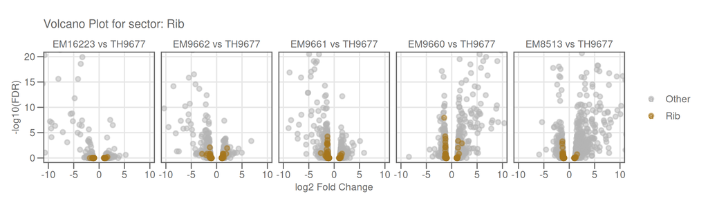

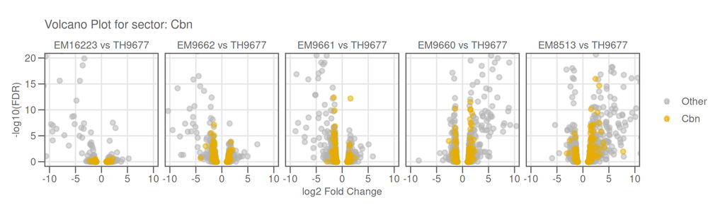

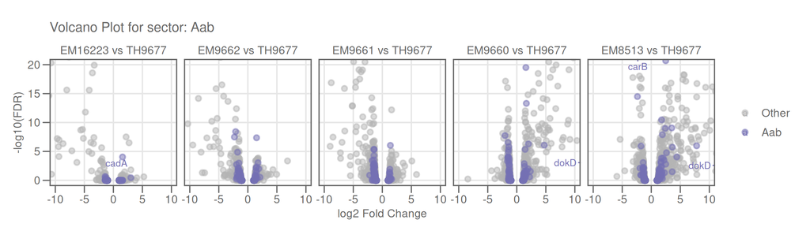

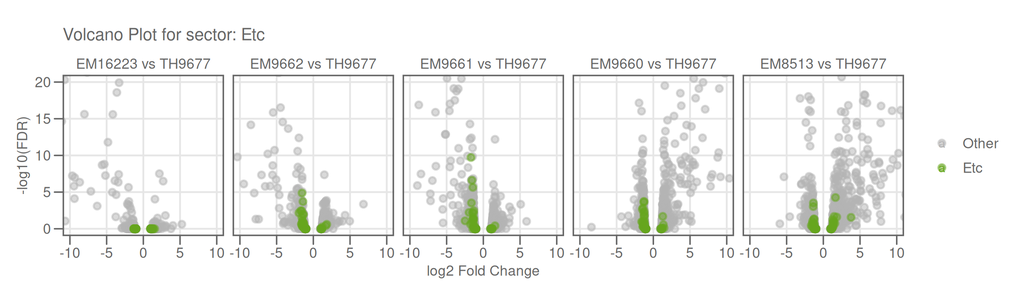

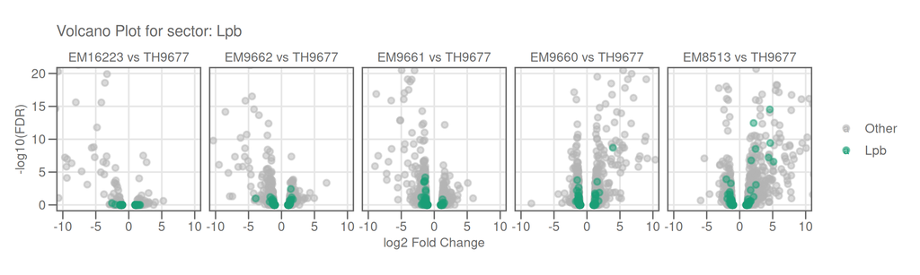

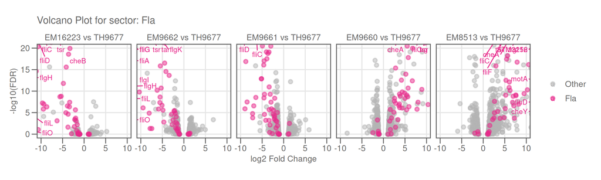

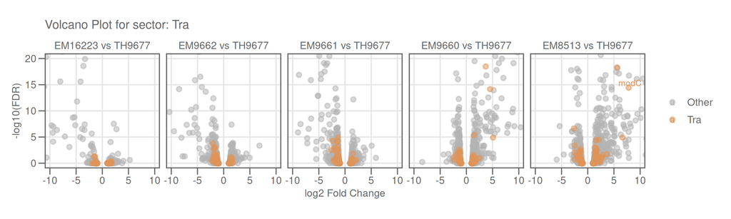

```r
for (sect in sectors_sorted[-1]) {
  sector_col <- match(sect, sectors_sorted[-1]) + 1
  plot_sector_fc <- df_fc %>%
    filter(group2 == "TH9677") %>%
    mutate(comparison = factor(paste(group1, "vs", group2), paste(strains_sorted, "vs TH9677"))) %>%
    mutate(sector_color = factor(ifelse(sector_short == sect, sect, "Other"), c("Other", sect))) %>%
    arrange(fct_relevel(sector_short, sect, after = Inf)) %>%
    ggplot(aes(
      x = fold_change,
      y = -log10(p_fdr),
      color = sector_color,
      label = ifelse(sector_short == sect & p_fdr < 0.05 & abs(fold_change) >= 1, gene_name_short, "")
    )) +
    geom_point(alpha = 0.5) +
    geom_text_repel(size = 3, max.overlaps = 1) +
    custom_theme() +
    scale_color_manual(values = custom_colors[c(1, sector_col)]) +
    labs(
      title = paste0("Volcano Plot for sector: ", sect),
      x = "log2 Fold Change",
      y = "-log10(FDR)",
      color = "Sector"
    ) +
    theme(legend.position = "right", aspect.ratio = 1) +
    facet_wrap(~comparison, ncol = 5) +
    coord_cartesian(xlim = c(-10, 10), ylim = c(0, 20))

  print(plot_sector_fc)
  save_plot(
    plot_sector_fc,
    width = 10, height = 3,
    pl_name = paste0("plot_fc_", sect)
  )
}
```

### Trends in protein allocation (mass fraction)

- calculate mass fractions for each protein and condition
- then aggregate mass fractions of all proteins assigned to a sector

```r
df_mass_frac <- df_annotated %>%
  group_by(mutant, replicate, sector_short) %>%
  summarize(mass_fraction = sum(mass_fraction, na.rm = TRUE), .groups = "drop") %>%
  ungroup()
```

- these figures give a first, broad overview about shifts in mass fractions
- we can clearly see that the `Fla` sector (flagella) and the Ribosome sector (`Rib`) are anti-correlated

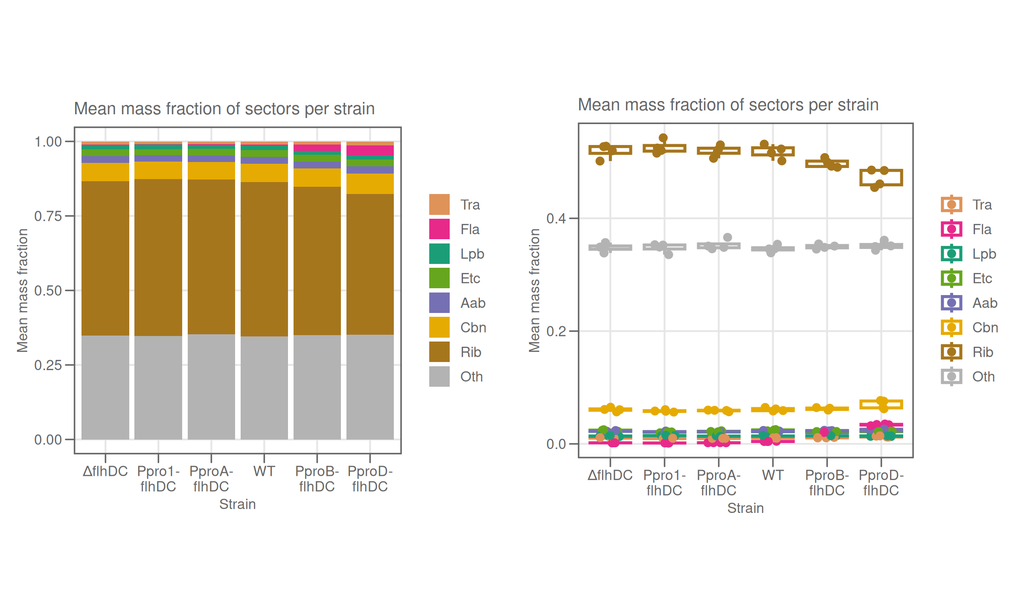

```r
plot_mass_frac_bars <- df_mass_frac %>%
  group_by(mutant, sector_short) %>%
  summarize(
    .groups = "drop",
    mean_mass_fraction = mean(mass_fraction, na.rm = TRUE),
    sd_mass_fraction = sd(mass_fraction, na.rm = TRUE)
  ) %>%
  mutate(mutant = factor(linebreak(mutant), linebreak(mutants_sorted))) %>%
  ggplot(aes(x = mutant, y = mean_mass_fraction, fill = fct_rev(sector_short))) +
  geom_bar(stat = "identity", position = "stack") +
  custom_theme() +
  scale_fill_manual(values = rev(custom_colors)) +
  labs(
    title = "Mean mass fraction of sectors per strain",
    x = "Strain",
    y = "Mean mass fraction",
    fill = "Sector"
  ) +
  theme(legend.position = "right", aspect.ratio = 1)

plot_mass_frac_points <- df_mass_frac %>%
  mutate(mutant = factor(linebreak(mutant), linebreak(mutants_sorted))) %>%
  ggplot(aes(x = mutant, y = mass_fraction, color = fct_rev(sector_short))) +
  geom_boxplot(position = "identity", outliers = FALSE, median.linetype = NA, alpha = 0.5) +
  geom_point(position = position_jitter(width = 0.2, height = 0)) +
  custom_theme() +
  scale_color_manual(values = rev(custom_colors)) +
  labs(
    title = "Mean mass fraction of sectors per strain",
    x = "Strain",
    y = "Mean mass fraction"
  ) +
  theme(legend.position = "right", aspect.ratio = 1)

save_plot(plot_mass_frac_bars, width = 6, height = 6)
save_plot(plot_mass_frac_points, width = 6, height = 6)
print(ggarrange(plot_mass_frac_bars, plot_mass_frac_points, ncol = 2))
```

- this is a more detailed view on the mass fraction per sector across conditions (strains)
- each subplot is scaled to a different, individual range

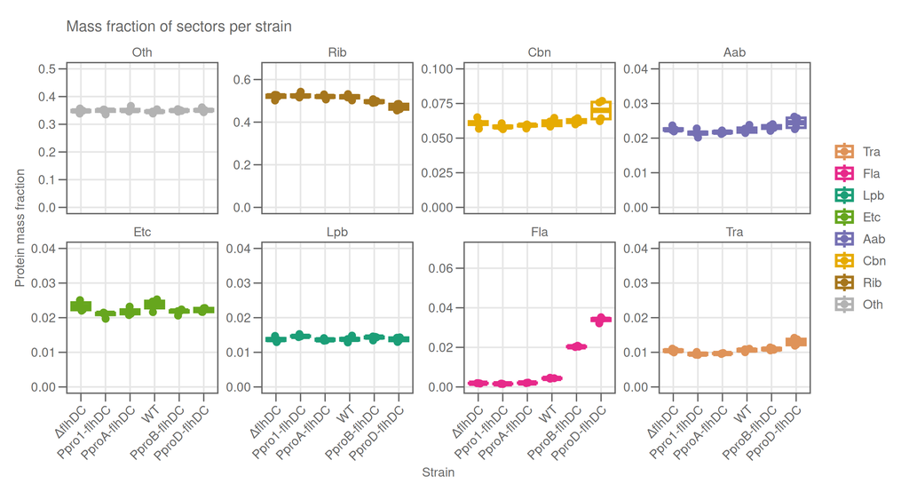

```r
list_y_lims <- list(
  sector_short == "Oth" ~ scale_y_continuous(limits = c(0, 0.5)),
  sector_short == "Rib" ~ scale_y_continuous(limits = c(0, 0.65)),
  sector_short == "Cbn" ~ scale_y_continuous(limits = c(0, 0.1)),
  sector_short == "Aab" ~ scale_y_continuous(limits = c(0, 0.04)),
  sector_short == "Etc" ~ scale_y_continuous(limits = c(0, 0.04)),
  sector_short == "Lpb" ~ scale_y_continuous(limits = c(0, 0.04)),
  sector_short == "Fla" ~ scale_y_continuous(limits = c(0, 0.07)),
  sector_short == "Tra" ~ scale_y_continuous(limits = c(0, 0.04))
)

plot_mass_frac_sectors <- df_mass_frac %>%
  ggplot(aes(x = mutant, y = mass_fraction, color = fct_rev(sector_short))) +
  geom_boxplot(position = "identity", outliers = FALSE, alpha = 0.5) +
  geom_point(position = position_jitter(width = 0.1, height = 0)) +
  custom_theme() +
  scale_color_manual(values = rev(custom_colors)) +
  labs(
    title = "Mass fraction of sectors per strain",
    x = "Strain",
    y = "Protein mass fraction"
  ) +
  theme(legend.position = "right", aspect.ratio = 1, axis.text.x = element_text(angle = 45, hjust = 1)) +
  facet_wrap(~sector_short, ncol = 4, scales = "free_y") +
  ggh4x::facetted_pos_scales(y = list_y_lims)

save_plot(plot_mass_frac_sectors, width = 10, height = 5.5)
print(plot_mass_frac_sectors)
```

### Most abundant proteins per sector

- sector overviews are already informative, but it is also necessary to look at the most important single proteins
- we need to know which proteins in which sector are most abundant by mass (thus also contribute most to sector changes)
- for this purpose, all proteins are summarized by the mean mass fraction over all replicates and conditions, and then ranked
- the top 10 proteins per sector are visualized as bar chart

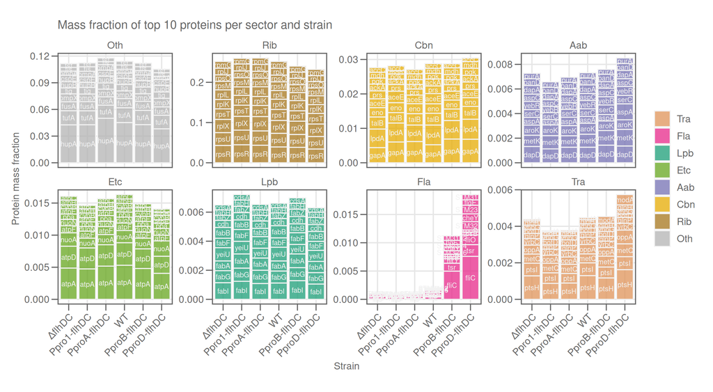

```r
df_mass_frac_top10 <- df_annotated %>%
  group_by(uniprot_id, gene_name_short, sector, sector_short, mutant) %>%
  summarize(
    .groups = "drop",
    mean_mass_fraction = mean(mass_fraction, na.rm = TRUE),
    sd_mass_fraction = sd(mass_fraction, na.rm = TRUE)
  ) %>%
  group_by(sector_short, uniprot_id) %>%
  mutate(condsum_mass_fraction = sum(mean_mass_fraction, na.rm = TRUE)) %>%
  group_by(sector_short) %>%
  mutate(rank_mass_fraction = rank(condsum_mass_fraction)) %>%
  filter(rank_mass_fraction >= sort(unique(rank_mass_fraction), decreasing = TRUE)[10]) %>%
  arrange(desc(rank_mass_fraction)) %>%
  select(-condsum_mass_fraction, -rank_mass_fraction) %>%
  ungroup()

plot_mass_frac_top10 <- df_mass_frac_top10 %>%
  ggplot(aes(x = mutant, y = mean_mass_fraction, fill = fct_rev(sector_short))) +
  geom_col(position = "stack", col = grey(0.95), alpha = 0.75, linewidth = 0.5) +
  geom_text(aes(label = gene_name_short), color = grey(0.95), position = position_stack(vjust = 0.5), size = 2.5) +
  custom_theme() +
  scale_fill_manual(values = rev(custom_colors)) +
  labs(
    title = "Mass fraction of top 10 proteins per sector and strain",
    x = "Strain",
    y = "Protein mass fraction"
  ) +
  theme(legend.position = "right", aspect.ratio = 1, axis.text.x = element_text(angle = 45, hjust = 1)) +
  facet_wrap(~sector_short, ncol = 4, scales = "free_y")

save_plot(plot_mass_frac_top10, width = 10, height = 5.5)
print(plot_mass_frac_top10)
```

### Trends for specific sectors or groups

- two sectors of particular interest are the `Fla` (flagella) and `Rib` (ribosome) sectors, as they show strong anti-correlation across conditions
- we can visualize the mass fraction of these two sectors across conditions on protein level

#### Ribosomal proteins

- it becomes clear that ribosomal mass is not dependent on single changed protein
- rather a general, slight shift in abundance of all R-proteins together creates the effect on the sector level
- this is in line with previous literature

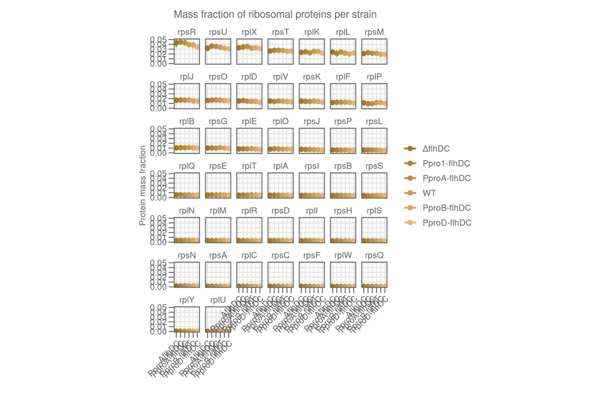

```r
plot_mass_frac_ribo <- df_annotated %>%
  group_by(uniprot_id, gene_name_short, sector, sector_short, mutant) %>%
  summarize(
    .groups = "drop",
    mean_mass_fraction = mean(mass_fraction, na.rm = TRUE),
    sd_mass_fraction = sd(mass_fraction, na.rm = TRUE)
  ) %>%
  filter(sector_short == "Rib", str_detect(gene_name_short, "[Rr]ps|[Rr]pl")) %>%
  mutate(gene_name_short = fct_relevel(
    gene_name_short,
    unique(gene_name_short[order(mean_mass_fraction, decreasing = TRUE)])
  )) %>%
  ggplot(aes(x = mutant, y = mean_mass_fraction, color = mutant)) +
  geom_errorbar(
    width = 0.2, position = position_dodge(width = 0.75),
    aes(
      ymin = mean_mass_fraction - sd_mass_fraction,
      ymax = mean_mass_fraction + sd_mass_fraction
    )
  ) +
  geom_point(position = position_dodge(width = 0.75)) +
  custom_theme() +
  scale_color_manual(values = colorspace::lighten(custom_colors[2], seq(0, 0.5, 0.1))) +
  labs(
    title = "Mass fraction of ribosomal proteins per strain",
    x = "",
    y = "Protein mass fraction"
  ) +
  theme(legend.position = "right", aspect.ratio = 1, axis.text.x = element_text(angle = 45, hjust = 1)) +
  facet_wrap(~gene_name_short)

save_plot(plot_mass_frac_ribo, width = 8, height = 8)
print(plot_mass_frac_ribo)
```

#### Flagellar proteins

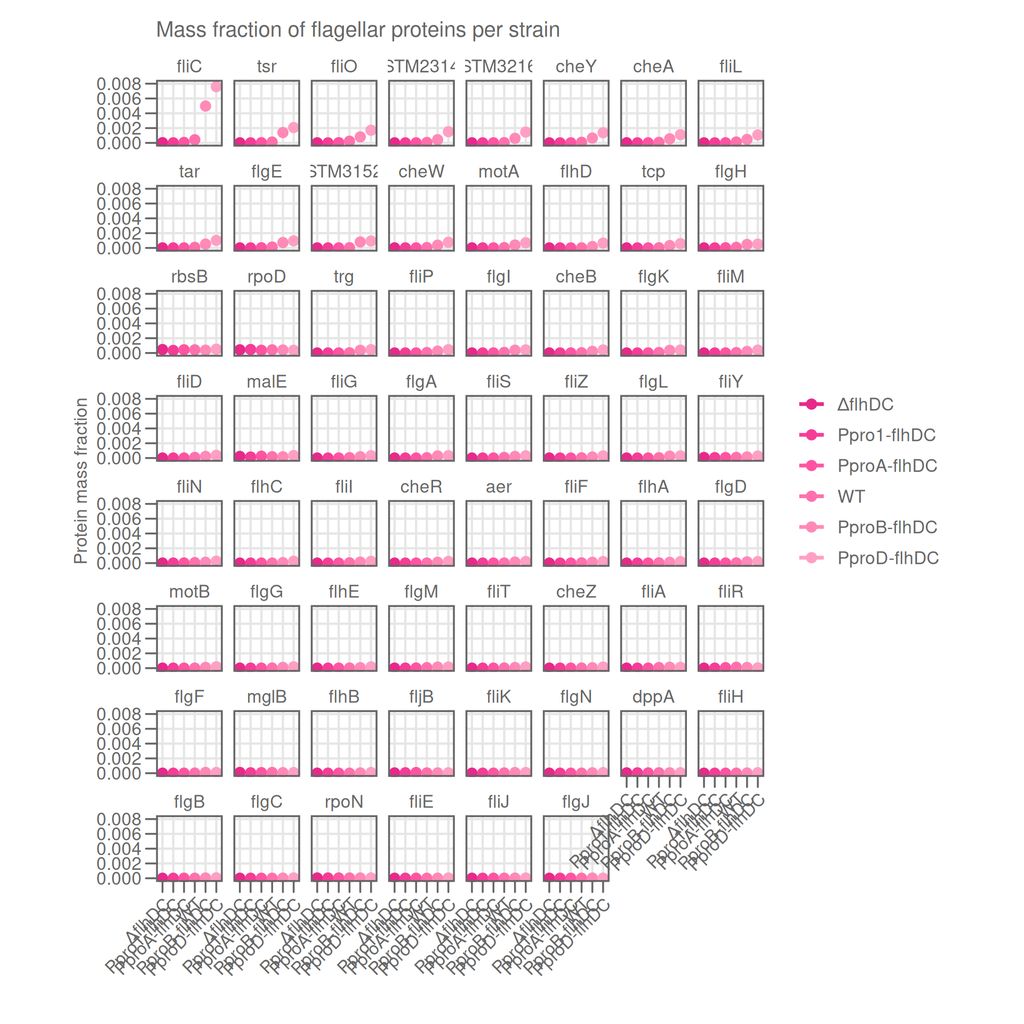

```r
plot_mass_frac_flag <- df_annotated %>%
  group_by(uniprot_id, gene_name_short, sector, sector_short, mutant) %>%
  summarize(
    .groups = "drop",
    mean_mass_fraction = mean(mass_fraction, na.rm = TRUE),
    sd_mass_fraction = sd(mass_fraction, na.rm = TRUE)
  ) %>%
  filter(sector_short == "Fla") %>%
  mutate(gene_name_short = fct_relevel(
    gene_name_short,
    unique(gene_name_short[order(mean_mass_fraction, decreasing = TRUE)])
  )) %>%
  ggplot(aes(x = mutant, y = mean_mass_fraction, color = mutant)) +
  geom_errorbar(
    width = 0.2, position = position_dodge(width = 0.75),
    aes(
      ymin = mean_mass_fraction - sd_mass_fraction,
      ymax = mean_mass_fraction + sd_mass_fraction
    )
  ) +
  geom_point(position = position_dodge(width = 0.75)) +
  custom_theme() +
  scale_color_manual(values = colorspace::lighten(custom_colors[7], seq(0, 0.5, 0.1))) +
  labs(
    title = "Mass fraction of flagellar proteins per strain",
    x = "",
    y = "Protein mass fraction"
  ) +
  theme(legend.position = "right", aspect.ratio = 1, axis.text.x = element_text(angle = 45, hjust = 1)) +
  facet_wrap(~gene_name_short)

save_plot(plot_mass_frac_flag, width = 8, height = 8)
print(plot_mass_frac_flag)
```

## Comparison of mass fraction and growth rate

### Import growth rate data

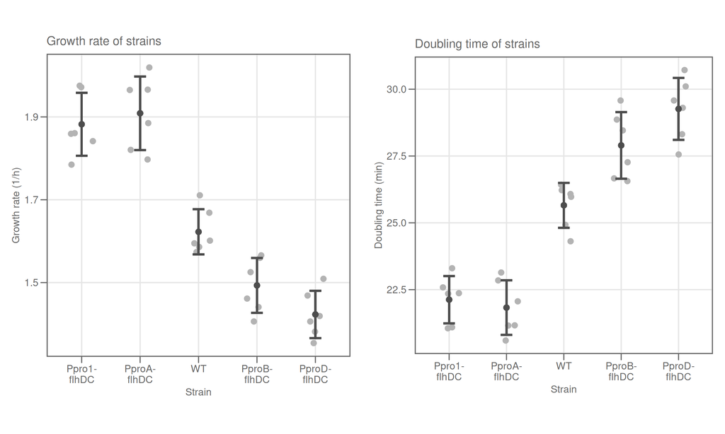

```r
df_growth_rate <- read_csv("../tables/population_growth_mutants.csv", show_col_types = FALSE) %>%
  select(strain, experiment_day, tech_rep, doubling_time_min) %>%
  rename(replicate = experiment_day) %>%
  mutate(
    replicate = as.integer(str_remove(replicate, "R")),
    mutant = recode_values(strain, from = strains_sorted, to = mutants_sorted),
    mutant = factor(mutant, mutants_sorted)
  ) %>%
  filter(!is.na(mutant)) %>%
  group_by(strain, mutant, replicate) %>%
  summarize(doubling_time_min = mean(doubling_time_min, na.rm = TRUE), .groups = "drop") %>%
  mutate(growth_rate_1h = log(2) / doubling_time_min * 60)

plot_growth_rate <- df_growth_rate %>%
  filter(mutant %in% mutants_sorted[2:6]) %>%
  group_by(mutant) %>%
  mutate(mean_mu = mean(growth_rate_1h), sd_mu = sd(growth_rate_1h)) %>%
  mutate(mutant = factor(linebreak(mutant), linebreak(mutants_sorted))) %>%
  ggplot(aes(x = mutant, y = growth_rate_1h)) +
  geom_point(color = grey(0.7), position = position_jitter(width = 0.2, height = 0)) +
  geom_point(aes(x = mutant, y = mean_mu), color = grey(0.3)) +
  geom_errorbar(
    color = grey(0.3),
    width = 0.2, position = position_dodge(width = 0.75),
    aes(
      ymin = mean_mu - sd_mu,
      ymax = mean_mu + sd_mu
    )
  ) +
  custom_theme(aspect.ratio = 1) +
  labs(
    title = "Growth rate of strains",
    x = "Strain",
    y = "Growth rate (1/h)"
  )

plot_doubling_time <- df_growth_rate %>%
  filter(mutant %in% mutants_sorted[2:6]) %>%
  group_by(mutant) %>%
  mutate(mean_dt = mean(doubling_time_min), sd_dt = sd(doubling_time_min)) %>%
  mutate(mutant = factor(linebreak(mutant), linebreak(mutants_sorted))) %>%
  ggplot(aes(x = mutant, y = doubling_time_min)) +
  geom_point(color = grey(0.7), position = position_jitter(width = 0.2, height = 0)) +
  geom_point(aes(x = mutant, y = mean_dt), color = grey(0.3)) +
  geom_errorbar(
    color = grey(0.3),
    width = 0.2, position = position_dodge(width = 0.75),
    aes(
      ymin = mean_dt - sd_dt,
      ymax = mean_dt + sd_dt
    )
  ) +
  custom_theme(aspect.ratio = 1) +
  labs(
    title = "Doubling time of strains",
    x = "Strain",
    y = "Doubling time (min)"
  )

plot_mu_dt <- ggpubr::ggarrange(plot_growth_rate, plot_doubling_time, ncol = 2)
save_plot(plot_mu_dt, width = 10, height = 6)
print(plot_mu_dt)
```

### Correlation of growth rate and mass sector_mass_fractions

- previous analysis showed that the `Fla` and `Rib` sectors are strongly anti-correlated across conditions
- ribosome mass decreases with increasing flagella mass
- since ribosome mass is known to be positively correlated with growth rate, we expect decline of growth rate with increasing flagella

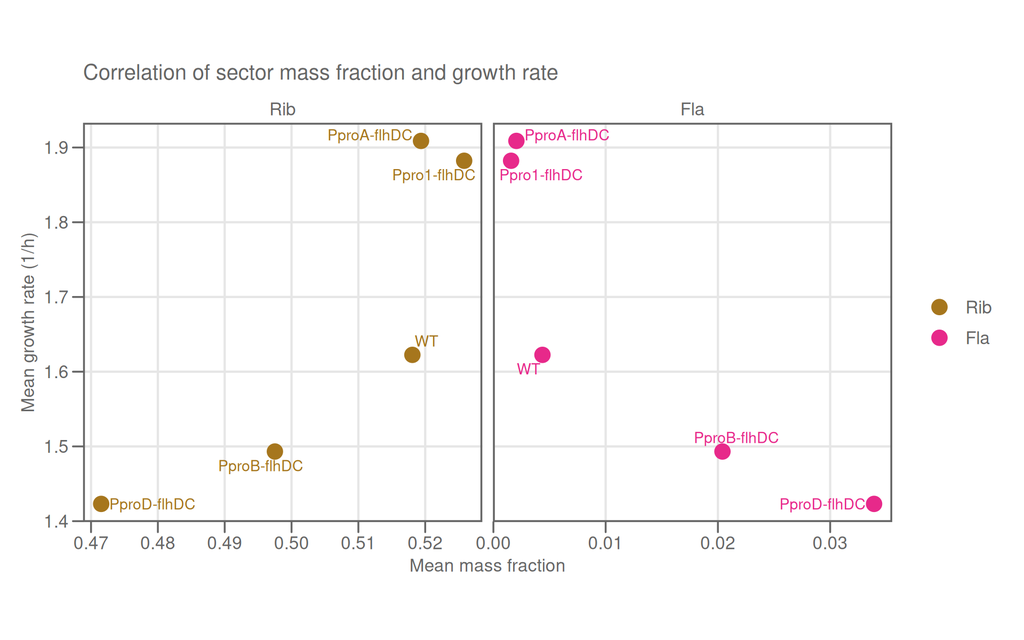

```r
plot_mass_vs_mu <- df_mass_frac %>%
  group_by(mutant, sector_short) %>%
  summarize(mean_mass_fraction = mean(mass_fraction, na.rm = TRUE)) %>%
  left_join(
    by = "mutant",
    df_growth_rate %>%
      group_by(mutant) %>%
      summarize(mean_growth_rate = mean(growth_rate_1h, na.rm = TRUE))
  ) %>%
  filter(sector_short %in% c("Rib", "Fla")) %>%
  filter(mutant %in% mutants_sorted[2:6]) %>%
  ggplot(aes(x = mean_mass_fraction, y = mean_growth_rate, color = sector_short)) +
  geom_point(size = 3) +
  ggrepel::geom_text_repel(aes(label = mutant, color = sector_short), size = 3) +
  custom_theme() +
  scale_color_manual(values = custom_colors[c(2, 7)]) +
  labs(
    title = "Correlation of sector mass fraction and growth rate",
    x = "Mean mass fraction",
    y = "Mean growth rate (1/h)",
    color = "Sector"
  ) +
  theme(legend.position = "right", aspect.ratio = 1) +
  facet_wrap(~sector_short, ncol = 2, scales = "free_x")

save_plot(plot_mass_vs_mu, width = 8, height = 5)
print(plot_mass_vs_mu)
```

## Data export

- in order to fit the cell economy model to experimental data, we export sector mass fraction to a TSV table

```r
df_mass_frac %>%
  full_join(
    by = "mutant",
    df_growth_rate %>%
      group_by(mutant) %>%
      summarize(
        mean_growth_rate = mean(growth_rate_1h, na.rm = TRUE),
        sd_growth_rate = sd(growth_rate_1h, na.rm = TRUE),
        mean_doubling_time = mean(doubling_time_min, na.rm = TRUE),
        sd_doubling_time = sd(doubling_time_min, na.rm = TRUE)
      )
  ) %>%
  write_tsv("../tables/sector_mass_fractions.tsv")
```